# Five approaches to the suppression of SARS-CoV-2 without intensive social distancing

August 27, 2020

## Five approaches to the suppression of SARS‑CoV‑2 without intensive social distancing

Here we investigate the potential effectiveness of five non-pharmaceutical approaches to suppression of SARS-CoV-2 without intensive social distancing measures such as school and workplace closures, shelter-in-place orders, and prohibitions on the gathering of people. We developed models for these five approaches to illustrate the similarities and differences among them and help to identify their distinctive strengths and weaknesses. We find that targeted approaches aimed at either infected individuals (widespread testing, tracing, quarantine) or uninfected individuals (certification) can be effective, but that these will have to be used in combination with generalized interventions such as mask wearing and limiting gatherings.

### Interventions

Our conceptual framework distinguishes between **targeted** and **generalized** interventions. Targeted interventions are interventions that are applied to specifically identified individuals in a population, typically based on infection or exposure status. Generalized interventions are behavioral or environmental interventions that are adopted broadly within a population. Targeted interventions are follow one of two strategies: targeting **infected** or **uninfected** individuals.

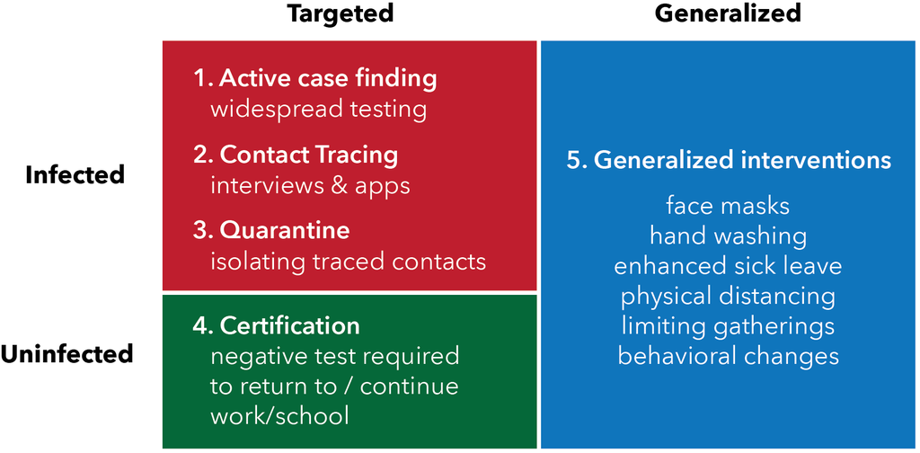

#### Targeting infected persons

*Targets infected people to limit transmission risk*

Each approach in this strategy represents an escalation of intervention.

1. **Active case finding.** All efforts that actively seek to identify cases. Equivalent to widespread testing.
- Testing health care workers and others with high occupational exposures
- Testing contacts of cases
- Adopting minimally exclusive testing criteria

It is assumed that identified cases are isolated and that onward transmission is eliminated or greatly reduced upon isolation. Active case finding contrasts with passive case finding, which we define as the detection of cases among symptomatic patients who present to medical services for diagnosis of symptoms and receive a test only after meeting some criteria.

2. **Contact tracing.** Identification, communication with, and monitoring of possible exposures of known cases.
- Interviewing cases or family members of cases
- Technological aids like cell phone apps

Contact tracing increases awareness among the subset of the population most likely to develop symptoms, decreases transmission from traced contacts who are encouraged to isolate, and increases the rate of case finding in the population. Prior to the 2020 COVID-19 pandemic, contact tracing had never been attempted at the scale that would be required to be effective in suppressing SARS-CoV-2.

3. **Quarantine.** Isolating traced contacts to the same degree that known cases are isolated.

Quarantine represents an escalation of intervention severity that amplifies the impact of contact tracing. The major effect of this approach is that it reduces the dependence on finding secondary cases (because secondary cases are already identified as contacts) and reduces or eliminates onward transmission from these cases (because the case is already in isolation when symptoms begin). Another effect is that it reduces the average contact rate within the population. Effectively, the portion of the population that is in quarantine is engaged in intensive social distancing, which can be thought of as a “partial lockdown” that is tunable based on the intensity of contact tracing.

#### Targeting uninfected persons

*Targeting healthy people to limit exposure*

4. **Certification.** Certification is an approach that relaxes social distancing in stages. Under this approach, individuals are certified to be infection free before returning to daily routines such as school, work, and shopping. Certification can be *durable* (valid for an extended period of time, for instance based on an antibody test) or *temporary* (valid for a short period of time, for instance because one has recently tested negative by RNA test). Durable certification doesn’t lead to a reduction in transmission, but may be essential for the provision of essential goods and services during periods of high transmission, as conceived by the “shield immunity” concept of Weitz et al.[^1]

We note that these strategies have different political, philosophical, ethical and behavioral implications. For instance, Strategy 1 may disincentivize care-seeking because receiving a positive test could preclude one from working whereas Strategy 2 may incentivize care-seeking because a negative diagnostic test or positive antibody test is required to work. Similarly, Strategy 1 prioritizes a right to work whereas Strategy 2 prioritizes a duty to protect. In addition, Strategy 1 and Strategy 2 approaches could be combined. But, because they are structurally different, we do not consider such combinations here.

#### Generalized interventions

*Aimed at reducing transmission or exposure broadly in a population. May be used in combination with targeted interventions*

5. **Generalized interventions.** Behavioral or environmental interventions that are adopted broadly within a population.
- wearing face masks
- improved hand hygiene
- improved cleaning and disinfection of surfaces
- greater provision of sick leave
- increased enforcement of school/workplace guidelines for staying home when sick
- contactless transactions
- use of infection barriers in stores, restaurants, and waiting areas
- distribution of hand sanitizer in public places
- behavioral change
- use of personal rather than public transport
- micro-social-distancing (e.g. limiting physical contact, queue spacing)
- public policies that limit aggregations of people (number of people allowed in stores, large events.)

May be added to either targeted strategy without modifying the topology of the flow diagram.

#### Summary of findings

Any of the preceding strategies may suppress transmission, but that suppression depends on achieving a certain level of effectiveness (reduction in transmission among isolated persons, intensity of contact tracing, frequency of certification, etc.) that varies according to the strategy.

- Interventions targeting **infected** individuals (active case finding, contact tracing, quarantine) are expected to work only when case ascertainment is high.
- Intervention targeting **uninfected** individuals (certification) is only expected to work in a narrow range of conditions (i.e. high frequency testing).

Regardless of the strategy adopted, a **large testing capacity is required** and success will depend on the effectiveness of generalized interventions.

Additionally, generalized interventions function as a “force multiplier.” In most realistic scenarios, **generalized interventions will be essential to achieve suppression**.

### Models

Below, we present conceptual models devised to be realistic for SARS-CoV-2, but they are not fit to data from any particular population. We studied the dynamics of active case finding, contact tracing, quarantine, and certification individually and in combination with generalized interventions after a “first wave” that infects a small fraction of the population. For comparison, we also consider the two limiting cases of maintaining intensive social distancing and doing nothing. The models are parameterized for a population of 10 million people, slightly larger than London (8.9 million) and New York City (8.3 million) and slightly smaller than the US state of Georgia (10.6 million), but they may be parameterized for a population of any size.

#### Questions

1. How much might generalized interventions (without targeted interventions) reduce the total outbreak size compared with reference scenarios?
2. When are contact tracing and quarantine most beneficial?
3. What benefit does quarantine add to contact tracing?
4. When can certification be effective?
5. How does the extent of presymptomatic transmission affect the choice of intervention strategy?

#### Model for Strategy targeting infected persons

Interventions:  
1. Active case finding 2. Contact tracing 3. Quarantine

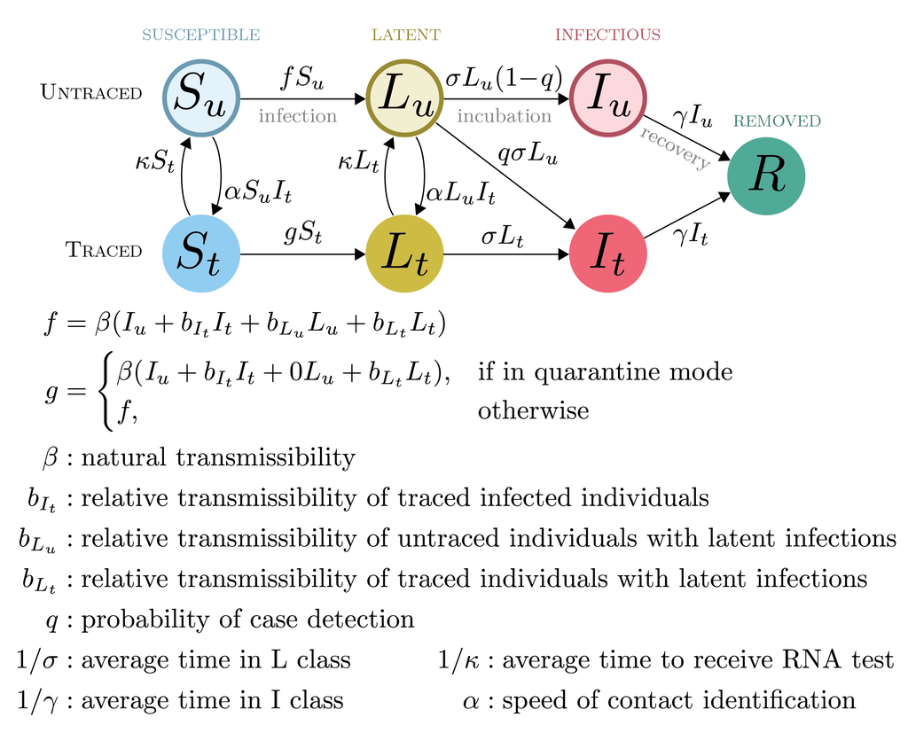

*Compartmental model for Strategy 1 interventions.*

As presymptomatic transmission is well documented and possibly quite important in the context of COVID-19 interventions [^2], our model replaces the usual $E$ (“exposed”) class with $L$ (“latent”) which may contribute to the force of infection. Upon displaying symptoms, untraced exposed individuals are assumed to enter isolation with probability $q$, reflecting the combined effects of both imperfect case ascertainment and contact tracing that may include less than 100% of known cases. Incomplete contact tracing could be either intentional or unintentional. It is assumed that all traced exposed individuals remain in the program as new cases upon the development of symptoms. Susceptible and exposed contacts of symptomatic cases are enrolled in the contact tracing program at rate $\alpha$. Traced individuals that do not develop symptoms are released from the program after a period of time $1/\kappa$. Transmission is assumed to occur through mass action.

**Basic reproduction number.** Using the next-generation matrix [^3] we obtained the following expression for the basic reproduction number of this model:

$$\begin{equation}
R_0 = \frac{\beta b_{L_u}}{\sigma} + \frac{\beta b_{I_u}(1-q)}{\gamma} + \frac{\beta b_{I_t}q}{\gamma}.
\end{equation}$$

Thus, overall, $R_0$ is a weighted sum of transmission contributions from the incubating, untraced and traced infectious individuals, respectively.

**Critical case finding value $q^\star$ at which $R_0=1$.

$$\begin{equation}
q^* = \frac{\beta b_{L_u} \gamma + \beta b_{I_u} \sigma - \gamma \sigma }{\beta b_{I_u} \sigma - \beta b_{I_t} \sigma}.
\end{equation}$$

Care should be taken in the interpretation of the force of infection functions $f$ and $g$. The force of infection is formulated such that a “natural” transmissibility $\beta$, assumed to represent the baseline contagiousness of an untraced symptomatic case circulating in the population, is multiplied by a factor ($b_{I_t} < 1$, $b_{L_u} < 1$, or $b_{L_t} < 1$) to represent the contagiousness of latent infections and isolated cases. This allows that infection from traced and untraced individuals may occur at different rates and thus we think of the transmissibility “attaching” to the class of the infected individual (traced or untraced). *Completely effective* isolation is represented by setting $b_{L_t} = 0$ and $b_{I_t}=0$. *Active case finding* is represented by setting $\alpha=0$ and $\kappa=0$ and tuning $q$ to represent different levels of active case finding. *Quarantine* is represented by setting $g = \beta (0 + b_{I_t} It + 0 + b_{L_t} L_t)$ and setting $b_{I_t}$ and $b_{L_t}$ to values that reflect the amount of transmission that may happen within a household where a person is quarantined. Completely effective quarantine is represented by setting $g=0$, $b_{L_t} = 0$ and $b_{I_t}=0$. This model reduces to the standard $SEIR$ model when $\alpha=0$, $\kappa=0$, $q=0$, $b_{I_t} = 0$, $b_{L_u} = 0$, and $b_{L_t} = 0$. The parameters $q$, $\kappa$, and $\alpha$ are considered to be control parameters, while the remaining parameters are considered to be natural.

#### Model for strategy targeting uninfected persons

Intervention: 4. Certification

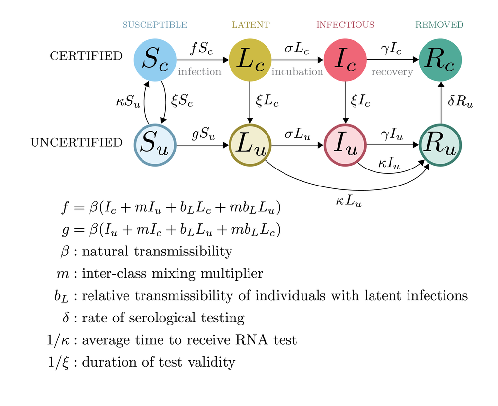

*Compartmental model for certifying infection status.*

This model supposes that there are both certified and uncertified persons who are susceptible, incubating, and symptomatic (designated $S$, $L$, and $I$), but two pools of removed ($R$). Again, it assumed that $L$ class individuals may contribute to the force of infection. The model allows that infection-free status may be conferred by either serological testing confirming past infection (durable certification) or having recently received a negative RNA test (temporary certification). We suppose that the primary purpose of certification is to change the patterns of contact between certified and uncertified people, i.e. with uncertified individuals practicing intensive social distancing by sheltering in place, not going to school or work, and not participating in large gatherings. In contrast to the Strategy targeting infected persons, here we assumed that $\beta$ attaches to encounters such that encounters within a class (certified-certified or uncertified-uncertified) have one rate of infectious contacts ($\beta$) while infectious encounters between classes (certified-uncertified) occur at another rate ($\beta m$), where $m<1$ is a factor that represents the reduction in mixing. Additionally, factor $b_L<1$ reduces the infectiousness of incubating infections compared with symptomatic infections. It is assumed that the temporary certification is valid for $1/\xi$ days. The parameters $\kappa$ and $\xi$ are considered to be control parameters, while the remaining parameters are considered to be natural.

**Basic reproduction number.** Assuming that there is no certification process prior to the start of the epidemic (i.e. ${S_c(0)=0, S_u(0)=1}$, and $\kappa=0$ initially), then the basic reproduction number is the standard form for an SEIR-type compartmental model:

$$\begin{equation}
R_0 = \frac{\beta b_L}{\sigma} + \frac{\beta}{\gamma}
\end{equation}$$

If certification is initiated before the start of the epidemic (i.e. if $S_c(0)>0$), the form of the basic reproduction number is much more complicated:

$$R_0=\frac{1}{2}\left({R}_{L_{c}L_{c}}+{R}_{L_{u}L_{u}}\right)+\frac{1}{2}\sqrt{\left({R}_{L_{c}L_{c}}-{R}_{L_{u}L_{u}}\right)^{2}+4{R}_{L_{c}L_{u}}{R}_{L_{u}L_{c}}}$$

The basic reproduction number is strictly increasing with the inter-class mixing multiplier, $m$. If the classes do not mix at all ($m=0$), then the basic reproduction number is equal to the greater of the two direct reproduction numbers:
$${R}_{0}=\max\left\{ {R}_{L_{c}L_{c}},{R}_{L_{u}L_{u}}\right\} =\frac{\beta}{\sigma+\min\left\{ \kappa,\xi\right\} }\left(\frac{\max\left\{ \kappa,\xi\right\} }{\kappa+\xi}\right)\left(b_{L}+\frac{\sigma}{\gamma+\min\left\{ \kappa,\xi\right\} }\right)$$

which is in general a lower bound for the value of the basic reproduction number. On the other hand, if the certification process has no impact on the mixing between classes ($m=1$), then the basic reproduction number will be much larger in general:

$${R}_{0}={R}_{L_{c}L_{c}}+{R}_{L_{u}L_{u}}$$

Similarly, this is an effective upperbound for ${R}_0$.Looking at the other control parameters, the basic reproduction number is strictly decreasing in the rate of certification testing, $\xi$. If certification remains valid indefinitely ($\xi=0$), then the risk of an outbreak is the same as if there were no certification process whatsoever and the basic reproduction number is as above:
$$\lim_{\xi\to 0} R_0 = \frac{\beta b_L}{\sigma} + \frac{\beta}{\gamma}$$
On the other hand, if certification has no effect ($\xi\to\infty$) then there is a significantly lower risk of an outbreak:
$$\lim_{\xi\to\infty} R_0 = \frac{\beta b_{L}}{\sigma+\kappa}+\frac{\beta}{\gamma+\kappa}\left(\frac{\sigma}{\sigma+\kappa}\right)$$
Hence, without certification, the ability to prevent an outbreak is determined solely by the rate of RNA testing ($\kappa$).

We obtain similar results for the limiting cases for the rate of RNA testing ($\kappa$):
$$\lim_{\kappa\to0}{R}_{0}=\frac{\beta b_L}{\sigma} + \frac{\beta}{\gamma}$$
and
$$\lim_{\kappa\to\infty} R_0 = \frac{\beta b_{L}}{\sigma+\xi}+\frac{\beta}{\gamma+\xi}\left(\frac{\sigma}{\sigma+\xi}\right).$$

#### Generalized interventions

Because transmission is the result of contagious contact, targeted and generalized interactions have multiplicative effects. In our model, generalized interventions are represented by multiplying $\beta$ by a factor less than one (typically 0.7, corresponding to a 30% reduction in transmission).

### Parameters

#### Assumptions:

**Transmission rate** $\beta=0.5$  
**Recovery rate** $\gamma=1/6$ (perdio of six days)  
**Basic reproduction number** $R_0=\beta/\gamma = 3.0$  
**Incubation rate** $\sigma=1/4$ (period of four days)

Incubating infections are 30% as contagious as symptomatic infections

Isolation reduces transmission by 90%, so  
$b_{I_t} = 0.1$, $b_{L_u} = 0.3$, and $b_{L_t} = 0.3 \times 0.1 = 0.03$.

For comparability between Strategy 1 and Strategy 2, we assume that the reduction in mixing due to certification is similar to the reduction in transmission due to isolation  
$m = b_{I_t} = 0.1$.

Social distancing reduces transmission by 60%

Generalized interventions reduce transmission by 30%.

We assume transmission is initiated with 1,000 infected individuals evenly distributed between incubating and symptomatic compartments of the non-target class (i.e. untraced or uncertified).

### Results

#### Generalized interventions alone

**How much might generalized interventions (without targeted interventions) reduce the total outbreak size compared with reference scenarios?**

The reference condition of continued social distancing is represented in the certification model by setting $\xi$ and $\kappa$ to 0 and setting $\beta_0$ to 40% of its original value. (For comparison, equivalent baseline conditions for the contact tracing model are provided in the supplmentary materials.) At the assumed level of social distancing, a large outbreak still occurs, ultimately infecting approximately half of the population. Social distancing combined with generalized interventions does not result in complete suppression, but reduces transmission to very close to the critical level.

A scenario with no social distancing and no targeted interventions is represented by setting $\xi$ and $\kappa$ to 0 and $m=1$. Unsurprisingly, the large majority of the population is infected under this condition and generalized interventions only reduce the total outbreak size by a relatively small amount (figure below, bottom). These results suggest that generalized interventions of the magnitude envisioned here are not sufficient to suppress transmission. If continued social distancing is not possible, then targeted interventions will be essential if infection of the majority of the population is to be prevented.

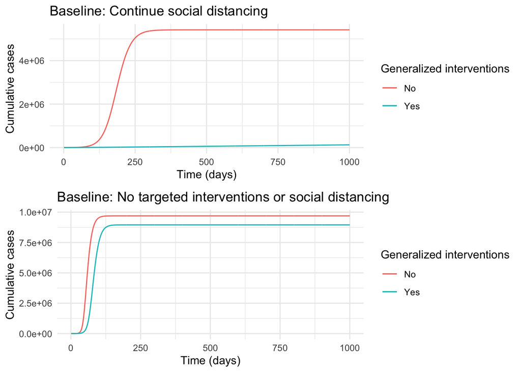

*Two baseline scenarios. The top plot assumes that transmissibility, $\beta$, is at 40% of its natural value. The bottom plot assumes that transmissibility, $\beta$, is at its natural value ($\beta = 0.5$). Both plots assume that generalized interventions reduce transmissibility by a further 30%. Other parameters are $b_L = 0.3$, $m=0.1$, $\gamma = 1/6$, $\sigma = 1/4$, $\kappa = 0$, $\delta = 1/10$, and $\xi = 1/7$.*

#### Contact tracing and quarantine

**When are contact tracing and quarantine most beneficial?**

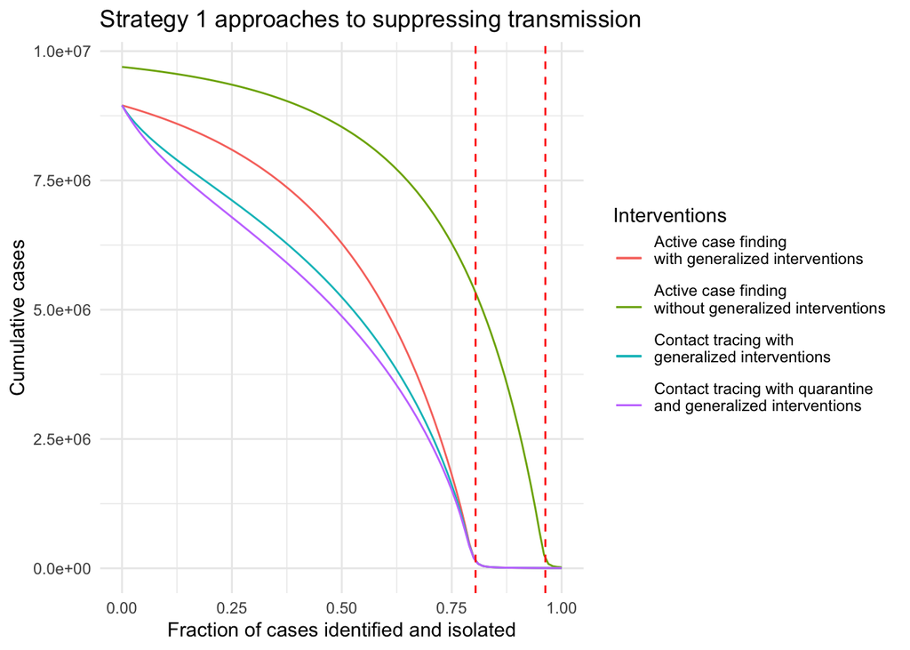

*Strategy 1 approaches to suppressing COVID-19 transmission as a function of case ascertainment ($q$). Dashed red lines show the critical value $q^*$ at which $R_0=1$ with and without generalized interventions. Other parameters are $b_{L_u} = 0.3$, $b_{L_t} = 0.03$, $b_{I_u} = 0.1$, $b_{I_t} = 0.1$, $\gamma = 1/6$, $\sigma = 1/4$, $\alpha = 0$, and $\kappa = 0$.

**What benefit does quarantine add to contact tracing?**

These results are possibly surprising. Particularly, why isn’t quarantine more effective compared with contact tracing, given that it has been such a longstanding public health strategy? Our model assumes that quarantined individuals are excluded from encounters in the general population. But, in recognition that traced contacts will often be family members and expecting that family members may be quarantined together, the model allows for transmission at 10% of the baseline value. We wondered if this small amount of transmission from quarantined individuals to family members accounts for the difference. To investigate this idea, we repeated the analysis setting $b_{I_t}=0$ and $b_{L_t}=0$, turning off transmission to or from traced contacts entirely. The overall shape of the effect of case identification on total outbreak size is similar, but shifted.

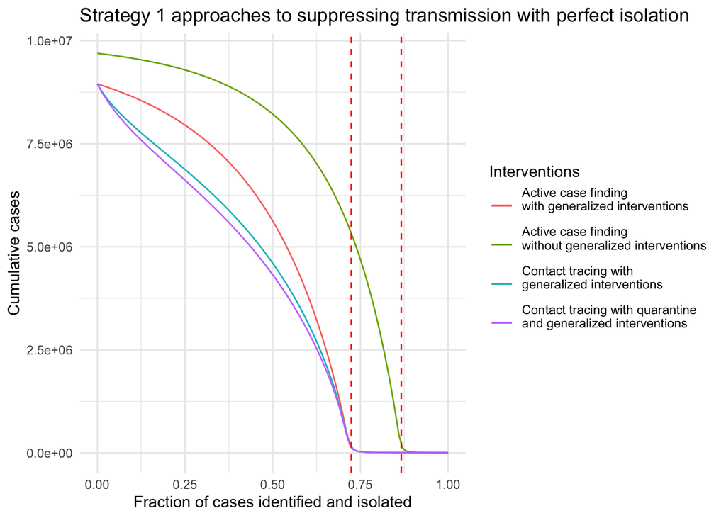

*Strategy 1 approaches to suppressing COVID-19 transmission as a function of case ascertainment ($q$) with perfect isolation. Dashed red lines show the critical value $q^*$ at which $R_0=1$ with and without generalized interventions. Other parameters are $b_{L_u} = 0.3$, $b_{L_t} = 0$, $b_{I_u} = 0.1$, $b_{I_t} = 0$, $\gamma = 1/6$, $\sigma = 1/4$, $\alpha = 0$, and $\kappa = 0$.*

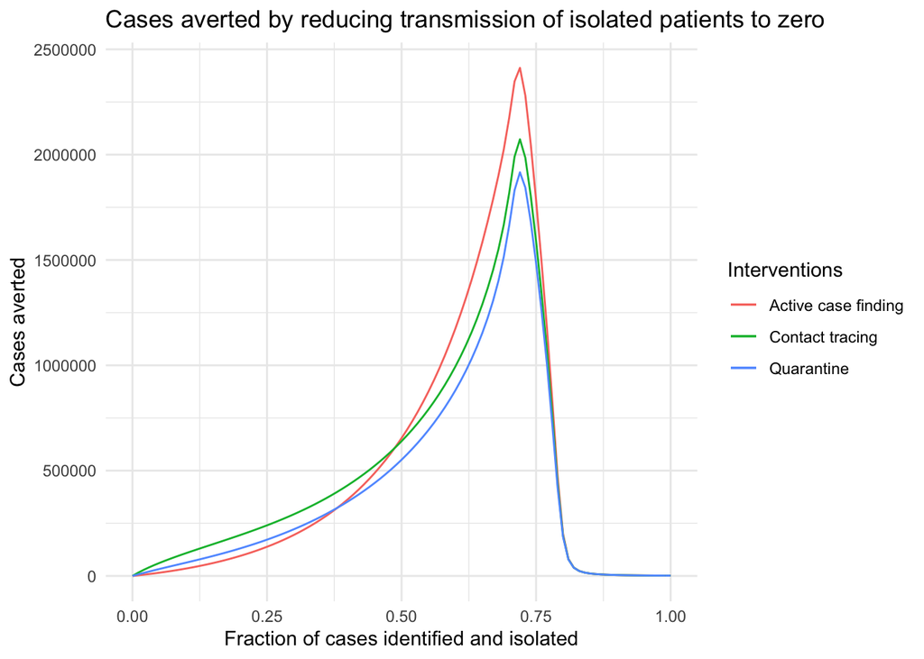

*Cases averted by reducing transmission from isolated patients from 10% to zero ($b_{L_t} = 0$, $b_{I_t} = 0$) as a function of case ascertainment ($q$). Other parameters are $b_{L_u} = 0.3$, $b_{I_u} = 0.1$, $\gamma = 1/6$, $\sigma = 1/4$, $\alpha = 0$, and $\kappa = 0$.*

#### Certification

**When can certification be effective?**

Here we look at certification with and without generalized interventions. To better understand the range of conditions under which certification can be effective, we examine the final outbreak size over a grid comprising all combinations of viral test validity from 7 to 21 days and for test waiting times from one to five days. Interestingly, in both cases there is a very sharp boundary between those testing regimes in which suppression of transmission is achieved (dark blue) and testing regimes where a very large outbreak ensues. These results suggest that it is virtually impossible to suppress transmission without generalized interventions. The “safe” region (dark blue) is larger when there are generalized interventions. Specifically, it appears that a test validity of 7-10 days together with a waiting time of no more than 3 days would achieve suppression. However, the sharpness of the boundary between suppression and a failure to suppress suggests that this approach is fragile, such that small inaccuracies in parameter values or model specification may cause the approach to fail.

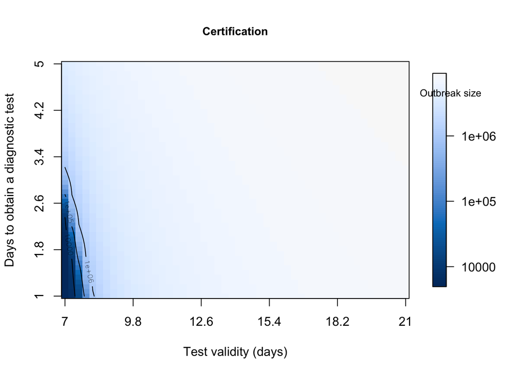

*Final outbreak size as a function of viral test validity ($1/\xi$) and test lag ($1/\kappa$) without generalized interventions. At the assumed value of presymptomatic transmission ($b_L=0.3$), there is only a very small region (dark blue) within which certification can prevent a major epidemic. Other parameters are $\beta = 0.5$, $m=0.1$, $\gamma = 1/6$, $\sigma = 1/4$, and $\delta = 0.1$.*

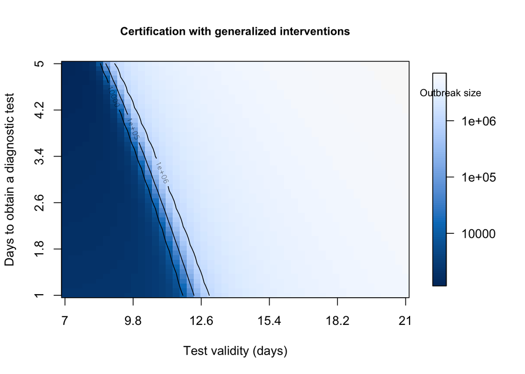

*Final outbreak size as a function of test validity ($1/\xi$) and test lag ($1/\kappa$) with generalized interventions. At the assumed value of presymptomatic transmission ($b_L=0.3$), there is modest region (dark blue) within which certification can prevent a major epidemic. Other parameters are $\beta = 0.5$, $m=0.1$, $\gamma = 1/6$, $\sigma = 1/4$, and $\delta = 0.1$.*

#### Presymptomatic transmission

**How does the extent of presymptomatic transmission affect the choice of intervention strategy?**

The preceding analyses assume that latent cases are 30% as infectious as symptomatic cases, but it is well known that “silent transmission” is a key component of COVID-19 epidemiology[^5]. Here we investigate how different levels of presymptomatic transmission influence the effectiveness of the containment strategies introduced here. First, we plot the total outbreak size against the assumed level of infectivity (i.e. the parameter $b_{L_u}$); for each level of $b_{L_u}$, the transmissibility of traced individuals is set to $b_{L_t} = 0.1 \times b_{L_u}$.

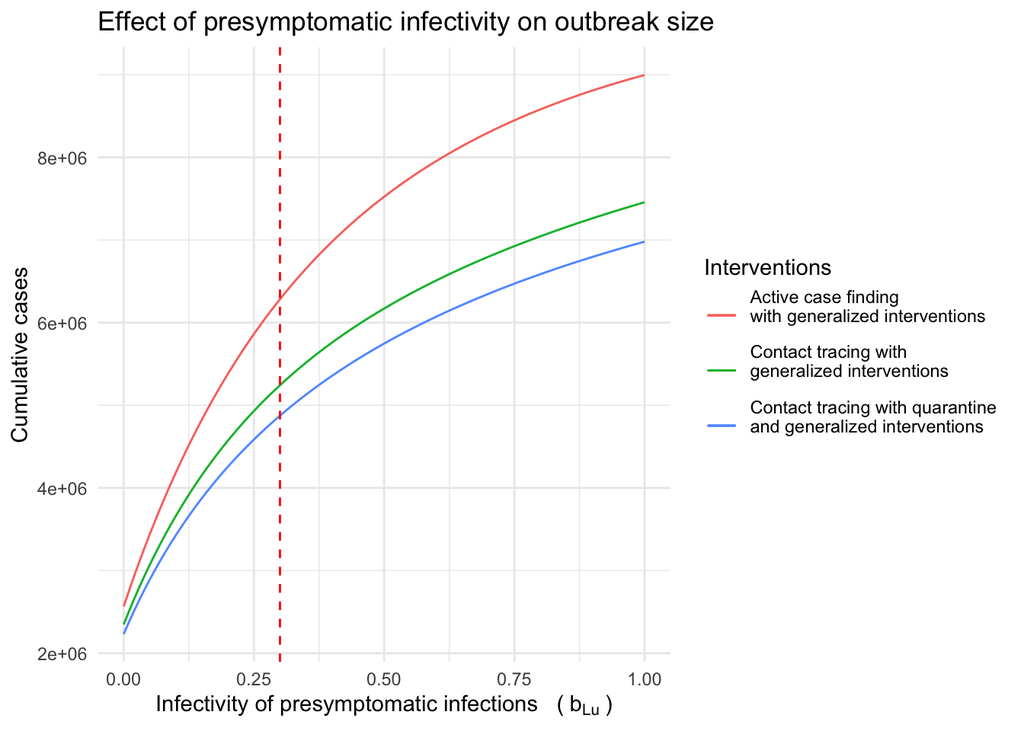

*Effect of presymptomatic infectivity on outbreak size for $0 < b_{L_u} < 1$. The vertical dashed line shows the default value of $b_{L_u} = 0.3$ for comparison with other figures. Other parameters are $\beta = 0.35$, $b_{I_u} = 0.1$, $\gamma = 1/6$, $\sigma = 1/4$, and $q = 0.5$.*

Next we look at the certification model at four different levels of $b_L$. Epidemic outcomes are summarized by plotting the contour for combinations of test validity ($1/\xi$) and test lag ($1/\kappa$) where the final outbreak size is 10,000. Because the transition is so sharp, this is effectively the “containment boundary” separating minor transmission and a major epidemic. Unsurprisingly, for presymptomatic transmission less then the default value of 0.3, a longer test validity and test lag may be tolerated without risking a major outbreak. However, even with no presymptomatic transmission (0% contour), the safe region remains relatively small with a maximum test validity of around two weeks. As presymptomatic transmission approaches the level of symptomatic transmission, the safe region dimininishes substantially.

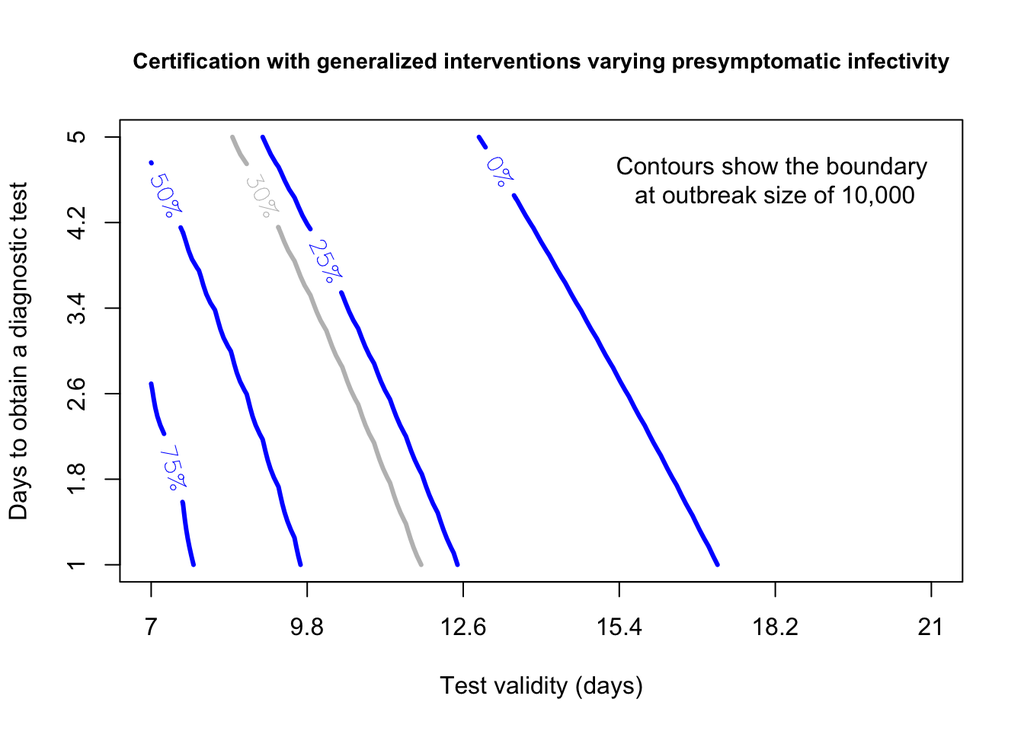

*Certification with generalized interventions for presymptomatic infectivity ($b_L$) assumed to be 0%, 25%, 50%, and 75% of the baseline value of $\beta = 0.35$ for transmission with generalized interventions. Combinations of test validity and days to obtain a test that are below the contour have total outbreak sizes less than 10,000 and may be considered to be “contained”. The default value of $b_L = 0.3$ is plotted in grey for comparison with Figure . Other parameters are $m=0.1$, $\gamma = 1/6$, $\sigma = 1/4$, and $\delta = 0.1$.*

#### Conculsions

**Are our parameters realistic for COVID-19?**

In most of the scenarios studied, we assumed that active case finding would yield case ascertainment rates of 50%. For context, this can be compared with either estimated case ascertainment rates or estimated symptomatic rates (which sets an upper bound on case acertainment through clinical diagnosis). In analysis of data from passengers on the Diamond Princess cruise ship, Mizumoto et al.[^6] estimated an overall asymptomatic proportion of 17.9% (equating to a symptomatic proportion of 82.1%). Among residents in a nursing home, 10 out of 23 (43.5%) were symptomatic at the time of testing [^7]. A review of multiple populations finds that the fraction of asymptomatic persons infected with SARS-CoV-2 may be 45-50%[^8]. For comparison, estimates of ascertainment in the US in for Spring 2020 are in the range of 1-10%[^9].

**Can we model combined strategies targeting both infected and uninfected individuals?**

Here we have modelled two targeted strategies for suppressing transmission without intensive social distancing (i.e. “lockdowns”). The models are structurally different, and neither is a special or limiting case of the other. A new model to study the effectiveness of using both strategies in combination (with or without generalized interventions), would be considerably more complicated, requiring approximately 16 states to represent the possible combinations of certified and uncertified persons that may be either traced or untraced and in one of the four primary infection states ($S$, $L$, $I$, and $R$). Such a model would be challenging to sensibly parameterize, but would nonetheless be a useful future step toward developing a complete understanding of transmission reduction via non-pharamceutical interventions for acute infectious diseases.

[^1]: Weitz *et al.* 2020. Modeling shield immunity to reduce COVID-19 epidemic spread. *Nat. Med.* **26**, 849–854.
[^2]: Moghadas *et al.* 2020. The implications of silent transmission for the control of COVID-19 outbreaks.  
    *Proc. Natl. Acad. Sci. U. S. A.* **in press**;  
    Tindale LC *et al.* 2020. Evidence for transmission of COVID-19 prior to symptom onset. *eLife* **9**, e57149.;  
    Rivett L *et al.* 2020. Screening of healthcare workers for SARS-CoV-2 highlights the role of asymptomatic carriage  
    in COVID-19 transmission. *eLife* **9**, e58728.
[^3]: Driessche P van den, Watmough J. 2002. Reproduction numbers and sub-threshold endemic equilibria for compartmental models of disease transmission. *Math. Biosci.* **180**, 29—48;  
    Heffernan JM, Smith RJ, Wahl LM. 2005. Perspectives on the basic reproductive ratio. *J. R. Soc. Interface* **2**, 281—293;  
    Diekmann O, Heesterbeek JAP, Roberts MG. 2010. The construction of next-generation matrices for compartmental epidemic models. *J. R. Soc. Interface* **7**, 873—885.
[^4]: Centers for Disease Control and Prevention. 2020. COVID-19 pandemic planning scenarios.  
    https://www.cdc.gov/coronavirus/2019-ncov/hcp/planning-scenarios.html;  
    Oran DP, Topol EJ. 2020. Prevalence of asymptomatic SARS-CoV-2 infection. *Ann. Intern. Med.* **in press**.
[^5]: Moghadas SM, Fitzpatrick MC, Sah P, Pandey A, Shoukat A, Singer BH, Galvani AP. 2020. The implications of silent transmission for the control of COVID-19 outbreaks. *Proc. Natl. Acad. Sci. U. S. A.* **in press**;  
    Tindale LC *et al.* 2020. Evidence for transmission of COVID-19 prior to symptom onset. *eLife* **9**, e57149.
[^6]: Mizumoto K, Kagaya K, Zarebski A, Chowell G. 2020. Estimating the asymptomatic proportion of coronavirus disease 2019 (COVID-19) cases on board the diamond princess cruise ship, yokohama, japan, 2020. *Euro Surveill.* **25**, 2000180.
[^7]: Kimball A *et al.* 2020. Asymptomatic and presymptomatic SARS-CoV-2 infections in residents of a Long-Term care skilled nursing facility - king county, washington, march 2020. *MMWR Morb. Mortal. Wkly. Rep.* **69**, 377—381.
[^8]: Oran DP, Topol EJ. 2020. Prevalence of asymptomatic SARS-CoV-2 infection. *Ann. Intern. Med.* **in press*.
[^9]: Lu FS, Nguyen AT, Link N, Santillana M. 2020. Estimating the prevalence of COVID-19 in the united states: Three complementary approaches. medRxiv 2020.04.18.20070821v1. *Epidemiology*;  
    Perkins A, Cavany SM, Moore SM, Oidtman RJ, Lerch A, Poterek M. 2020. Estimating unobserved SARS-CoV-2 infections in the united states medRxiv 2020.03.15.20036582v2. *Epidemiology*.